# **Anatomia di un Trasferimento**

### Analisi economica e statistica del calciomercato

**Candidato:** Andrea Gioia

**Matricola:** 169484

## **Introduzione e Obiettivi della Ricerca**

**Motivazione del Progetto:** Valutare sotto un punto di vista economico il calcio attraverso il suo mercato.

**Domande di Ricerca:**

1. **Analisi del Trend:** qual è l'andamento dei costi dei trasferimenti? Nel tempo è cambiato qualcosa?
2. **Impatto con uno shock:** in che modo il mercato reagisce agli shock della vita esterna?

## **Descrizione del Dataset**

**Fonte e Origine:**

- **Dataset:** Dati estratti da David Cariboo dal portale *Transfermarkt*.
- **Disponibilità:** [Dataset Kaggle consultabile qui](https://www.kaggle.com/datasets/davidcariboo/player-scores/data)
- **Copertura Temporale:** Stagioni dal 2010/2011 al 2023/2024

**Contenuto dei Dati:**

Il dataset include prezzi, valori stimati, risultati sportivi e informazioni sui giocatori.

## **1. La Visione d'Insieme**

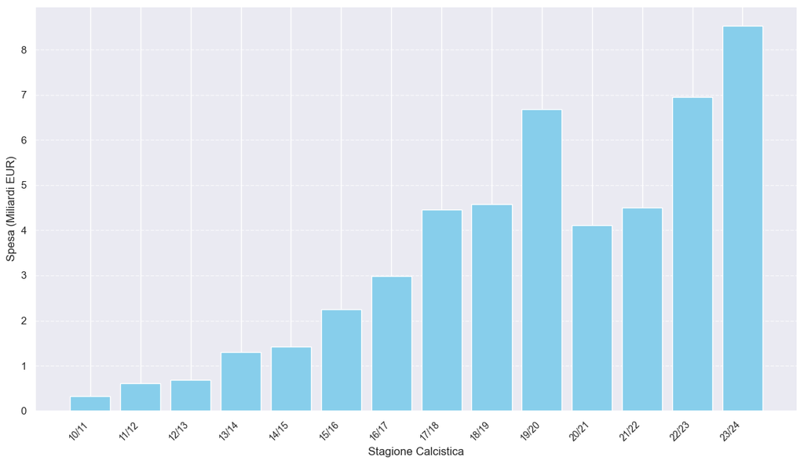

## **2. La Realtà: L'Inflazione del Talento**

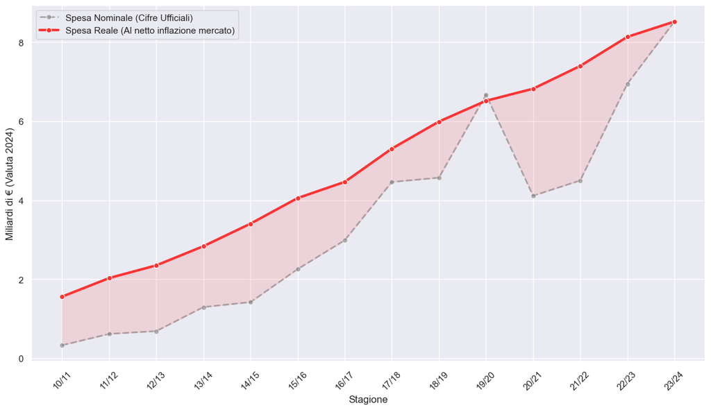

## **3. La Struttura del Mercato**

Forte correlazione (**R=0.95**) tra volume e spesa.  
P-value vicino allo 0.

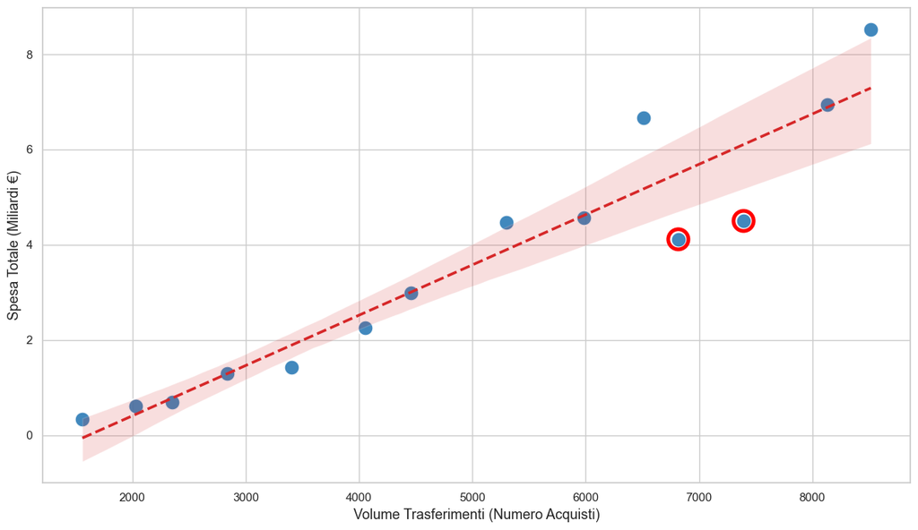

## **4. Inefficienza Strutturale**

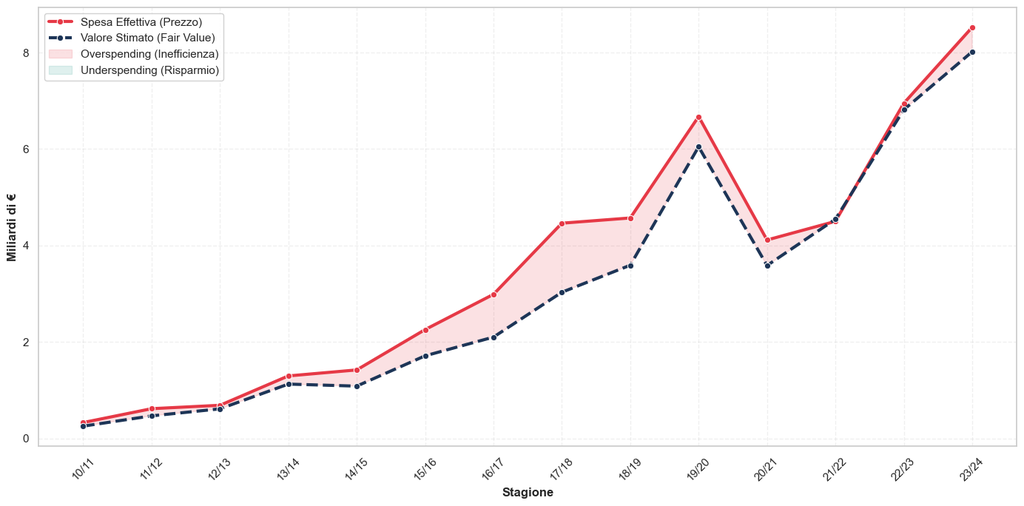

## **5. L'Impatto dello Shock**

L'unico momento di **"Underspending" (-1.0%)** coincide con la crisi di liquidità del COVID.  
*Solo uno shock esterno ha fermato la speculazione.*

[figure not shown]

## **6. "Premium Price"**

Media di **21.5% in più** del valore reale dei giocatori.

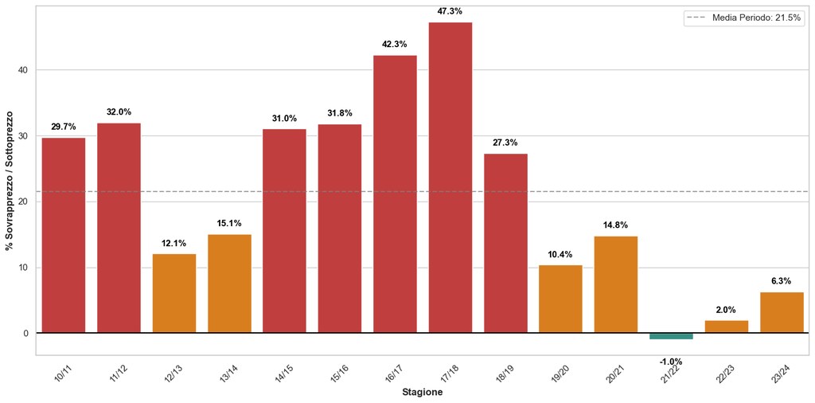

## Conclusioni

In risposta alle domande poste in introduzione, l'analisi ha evidenziato:

- **L'Anomalia COVID (2020-2022):** La correlazione si indebolisce. L'alto volume di scambi a fronte di una bassa spesa indica un cambiamento strutturale temporaneo (ricorso a prestiti/scambi) causato dalla crisi di liquidità.

**Sintesi:** "Il mercato calcistico mostra una rigidità strutturale (alta correlazione) ma è altamente vulnerabile all'inflazione dei prezzi e agli shock di liquidità esogeni."